# changes_sjl

S J Lax

5 May 2016

# Steph does unit testing!

## Setup

```r
load("H:/Repos/prevR/data/prevsim.rda")
registry_data <- prevsim

summary(registry_data)
```

```
##       time            status           age        sex
##  Min.   :   1.0   Min.   :0.000   Min.   :36.43   0:508
##  1st Qu.: 235.0   1st Qu.:0.000   1st Qu.:58.16   1:492
##  Median : 893.5   Median :1.000   Median :64.56
##  Mean   :1236.0   Mean   :0.558   Mean   :64.95
##  3rd Qu.:1868.2   3rd Qu.:1.000   3rd Qu.:71.88
##  Max.   :4444.0   Max.   :1.000   Max.   :95.32
##   entrydate          eventdate
##  Length:1000        Length:1000
##  Class :character   Class :character
##  Mode  :character   Mode  :character
##
##
##
```

Using Stuart’s custom function:

```r
test_output <- function(old_func, new_func) {
    expected <- old_func()
    actual <- new_func()
    test <- tryCatch(all(expected == actual),
                     error=function(cond) FALSE)
    if (test) {
        message("Success!")
    } else {
        message("Failure...")
        message("Expected:")
        print(expected)
        message("Actual:")
        print(actual)
    }
}
```

## counted_prevalence

```r
countprev_dev <- function() {
  counted_prevalence(registry_data$entrydate,
                     registry_data$eventdate,
                     registry_data$status,
                     start="2004-01-30", 9)
}
```

```r
registry_years <- c("2003-01-30", "2004-01-30", "2005-01-30", "2006-01-30", "2007-01-30", "2008-01-30",
                      "2009-01-30", "2010-01-30", "2011-01-30", "2012-01-30", "2013-01-30")
registry_start_year <- 2
registry_end_year <- 10

registry_data$status2 <- ifelse(registry_data$eventdate > "2013-01-30", 0, registry_data$status)
registry_data$indicator_censored_at_index <- registry_data$status2
registry_data$date_initial <- registry_data$entrydate
registry_data$date_event <- registry_data$eventdate
registry_data$indicator <- registry_data$status
registry_data$survival_time <- registry_data$time
registry_data$age_initial <- registry_data$age

countprev_current_output <- function() {

  counted_prevalence_current(registry_data, registry_years,
                             registry_start_year, registry_end_year)
}
```

```r
test_output(countprev_current_output, countprev_dev)
```

```
## Success!
```

## prev_chisq

```r
prevalence_total <- prevalence(Surv(time, status) ~ sex(sex) + age(age) + entry(entrydate),
                               registry_data, num_years_to_estimate = 10, cure = 10,
                               start='2004-01-30', num_reg_years=9)

by_year_total <- prevalence_total$simulated_cases

prevchisq_dev <- function() {
  prev_chisq(registry_data$entrydate,
            registry_data$eventdate,
            registry_data$status,
            start="2004-01-30", 9,
            by_year = by_year_total)
}
```

```r
prevchisq_current_output <- function() {
  prev_chisq_current(registry_data, registry_years, registry_start_year, registry_end_year, by_year = by_year_total)
}
```

```r
test_output(prevchisq_current_output, prevchisq_dev)
```

```
## Success!
```

## incidence_age_distribution

```r
registry_data_r <- registry_data[registry_data$entrydate >= "2004-01-30",]

incidence_age_distribution_dev <- function() {
  incidence_age_distribution(registry_data_r$age)
}
```

```r
incidence_age_distribution_current_output <- function() {
  incidence_age_distribution_current(registry_data, registry_years, registry_start_year, registry_end_year)
}
```

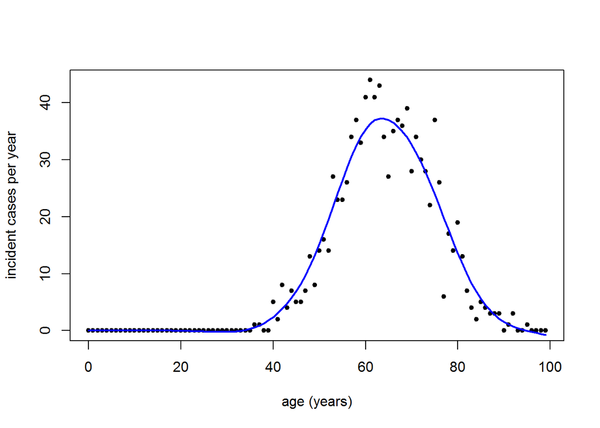

```
## Success!
```

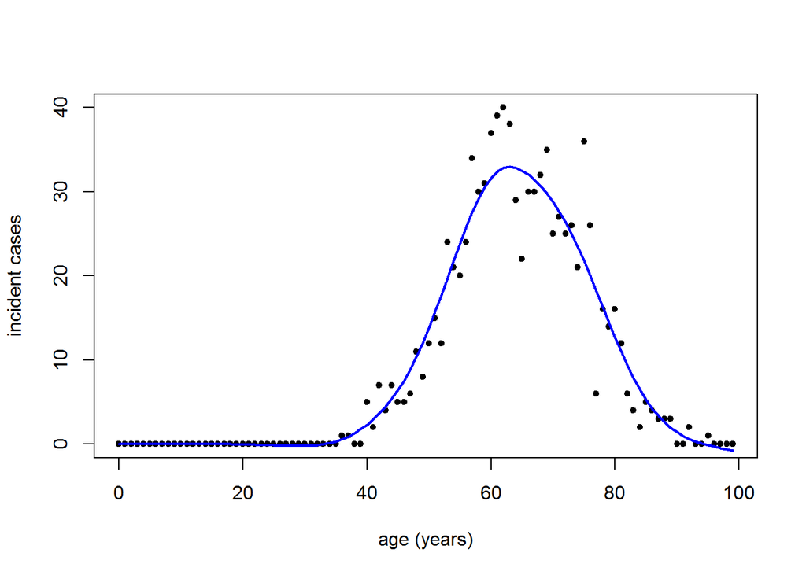

```r
test_output(incidence_age_distribution_current_output, incidence_age_distribution_dev)
```

## functional_form_age

```r
functional_form_age_dev <- function() {
  registry_data_r <- registry_data[registry_data$date_initial >=
                                         registry_years[registry_start_year] &
                                         registry_data$date_initial < registry_years[registry_end_year], ]
  functional_form_age(Surv(time, status) ~ age(age), registry_data_r)
}
```

```r
functional_form_age_current_output <- function() {
  functional_form_age_current(registry_data, registry_years, registry_start_year, registry_end_year)
}
```

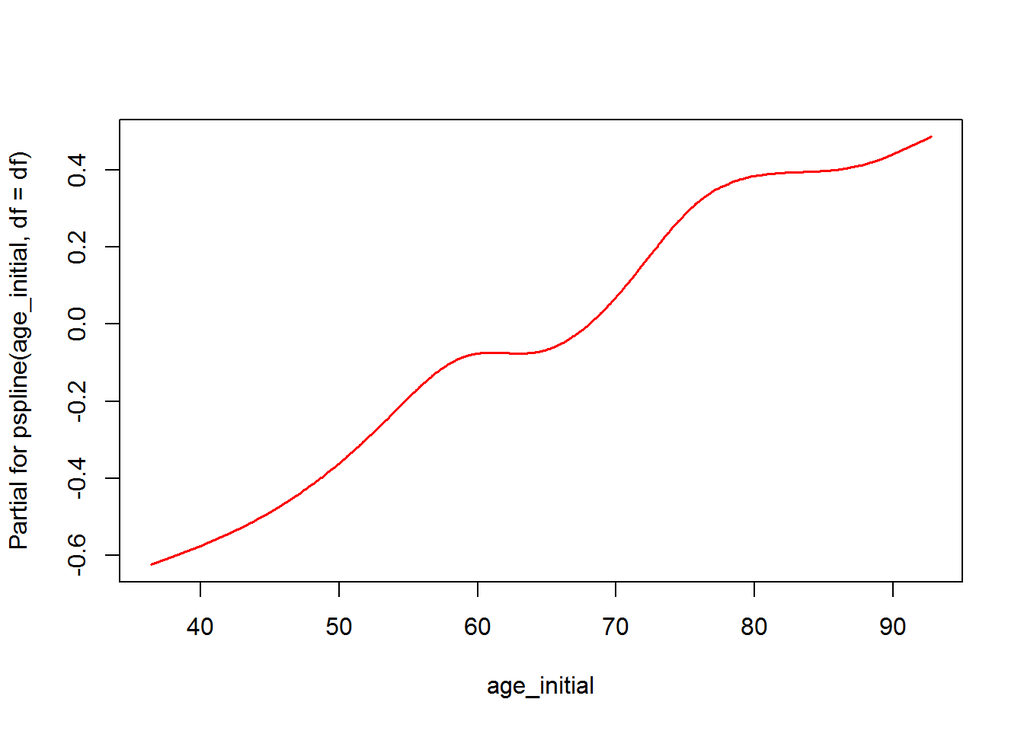

```
## Failure...
```

```
## Expected:
```

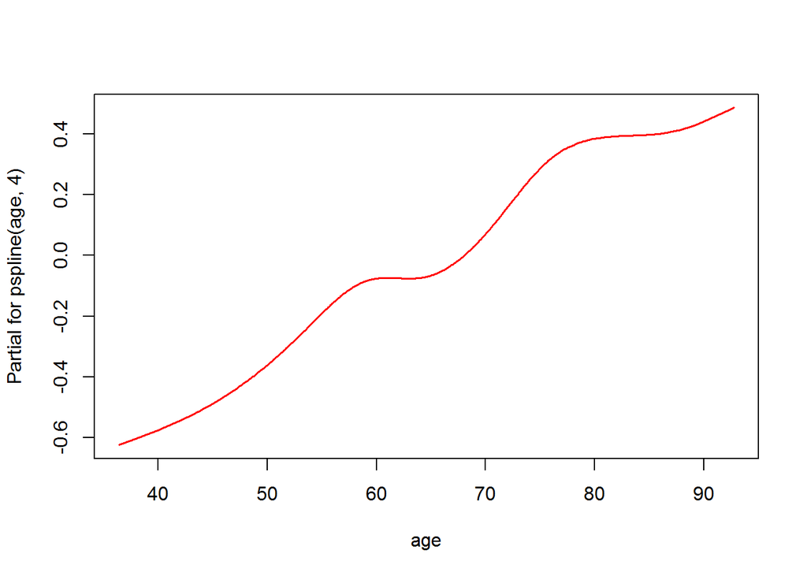

```
## [[1]]
## [1] 1
##
## [[2]]
```

```
##
## [[3]]
## Call:
## coxph(formula = Surv(survival_time, indicator) ~ pspline(age_initial,
##     df = df), data = data_r)
##
##   n= 792, number of events= 447
##
##                           coef    se(coef) se2      Chisq DF   p
## pspline(age_initial, df = 0.02263 0.004731 0.004731 22.87 1.00 1.7e-06
## pspline(age_initial, df =                            3.25 3.09 3.7e-01
##
##                   exp(coef) exp(-coef) lower .95 upper .95
## ps(age_initial)3      1.075     0.9302    0.3898     2.965
## ps(age_initial)4      1.158     0.8635    0.2193     6.117
## ps(age_initial)5      1.297     0.7712    0.1853     9.077
## ps(age_initial)6      1.547     0.6464    0.2151    11.124
## ps(age_initial)7      1.936     0.5166    0.2792    13.421
## ps(age_initial)8      1.795     0.5570    0.2623    12.291
## ps(age_initial)9      2.123     0.4711    0.3094    14.566
## ps(age_initial)10     2.867     0.3487    0.4165    19.743
## ps(age_initial)11     2.990     0.3345    0.4311    20.736
## ps(age_initial)12     2.964     0.3374    0.4163    21.107
## ps(age_initial)13     3.246     0.3080    0.3926    26.848
## ps(age_initial)14     3.646     0.2743    0.2873    46.261
##
## Iterations: 5 outer, 13 Newton-Raphson
##      Theta= 0.900102
## Degrees of freedom for terms= 4.1
## Concordance= 0.565  (se = 0.015 )
## Likelihood ratio test= 28.27  on 4.09 df,   p=1.216e-05
##
##
## [[4]]
##                 Wald Statistics          Response: Surv(survival_time, indicator)
##
##  Factor      Chi-Square d.f. P
##  age_initial 23.11      3    <.0001
##   Nonlinear   0.15      2    0.9284
##  TOTAL       23.11      3    <.0001
##
## [[5]]
##              Effects              Response : Surv(survival_time, indicator)
##
##  Factor        Low    High   Diff.  Effect  S.E.    Lower 0.95 Upper 0.95
##  age_initial   58.005 72.414 14.409 0.28319 0.13115 0.026144   0.54024
##   Hazard Ratio 58.005 72.414 14.409 1.32740      NA 1.026500   1.71640
```

```
## Actual:
```

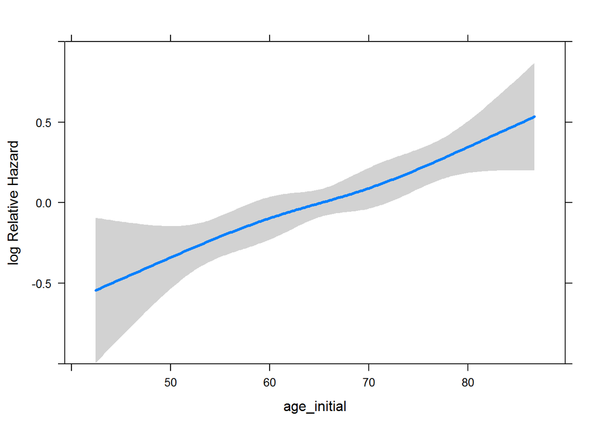

```
## [[1]]
## [1] 1
##
## [[2]]
```

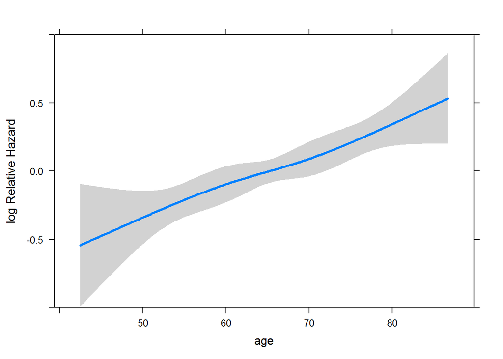

```
##
## [[3]]
## Call:
## coxph(formula = psp_surv_form, data = data)
##
##   n= 792, number of events= 447
##
##                         coef    se(coef) se2      Chisq DF   p
## pspline(age, 4), linear 0.02263 0.004731 0.004731 22.87 1.00 1.7e-06
## pspline(age, 4), nonlin                            3.25 3.09 3.7e-01
##
##           exp(coef) exp(-coef) lower .95 upper .95
## ps(age)3      1.075     0.9302    0.3898     2.965
## ps(age)4      1.158     0.8635    0.2193     6.117
## ps(age)5      1.297     0.7712    0.1853     9.077
## ps(age)6      1.547     0.6464    0.2151    11.124
## ps(age)7      1.936     0.5166    0.2792    13.421
## ps(age)8      1.795     0.5570    0.2623    12.291
## ps(age)9      2.123     0.4711    0.3094    14.566
## ps(age)10     2.867     0.3487    0.4165    19.743
## ps(age)11     2.990     0.3345    0.4311    20.736
## ps(age)12     2.964     0.3374    0.4163    21.107
## ps(age)13     3.246     0.3080    0.3926    26.848
## ps(age)14     3.646     0.2743    0.2873    46.261
##
## Iterations: 5 outer, 13 Newton-Raphson
##      Theta= 0.900102
## Degrees of freedom for terms= 4.1
## Concordance= 0.565  (se = 0.015 )
## Likelihood ratio test= 28.27  on 4.09 df,   p=1.216e-05
##
##
## [[4]]
##                 Wald Statistics          Response: Surv(time, status)
##
##  Factor     Chi-Square d.f. P
##  age        23.11      3    <.0001
##   Nonlinear  0.15      2    0.9284
##  TOTAL      23.11      3    <.0001
##
## [[5]]
##              Effects              Response : Surv(time, status)
##
##  Factor        Low    High   Diff.  Effect  S.E.    Lower 0.95 Upper 0.95
##  age           58.005 72.414 14.409 0.28319 0.13115 0.026144   0.54024
##   Hazard Ratio 58.005 72.414 14.409 1.32740      NA 1.026500   1.71640
```

```r
test_output(functional_form_age_current_output, functional_form_age_dev)
```

Although there is a failure here, the output from coxph looks exactly the same. A more detailed manual check shows this to be the case:

```r
dev <- functional_form_age_dev()
```

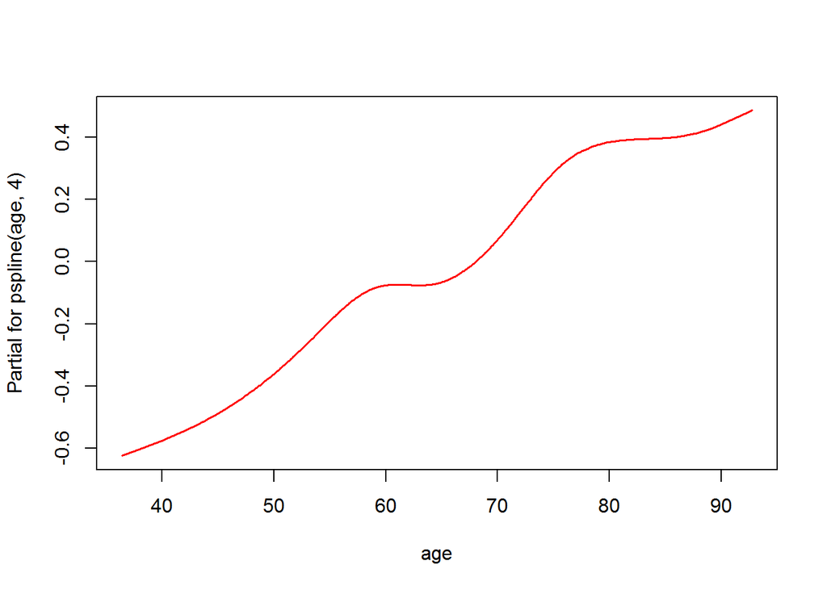

```r
cur <- functional_form_age_current_output()
```

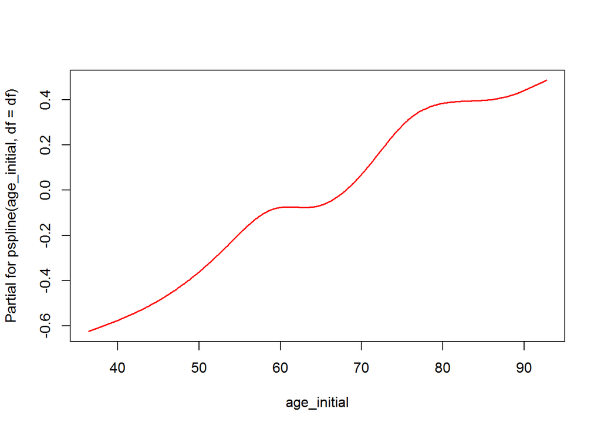

```r
dev[[1]] == cur[[1]]
```

```
## [1] TRUE
```

```r
dev[[4]] == cur[[4]]
```

```
##            Chi-Square d.f.    P
## age              TRUE TRUE TRUE
##  Nonlinear       TRUE TRUE TRUE
## TOTAL            TRUE TRUE TRUE
```

```r
dev[[5]] == cur[[5]]
```

```
##                Low High Diff. Effect S.E. Lower 0.95 Upper 0.95 Type
## age           TRUE TRUE  TRUE   TRUE TRUE       TRUE       TRUE TRUE
##  Hazard Ratio TRUE TRUE  TRUE   TRUE   NA       TRUE       TRUE TRUE
```

The list elements were compared by inspection and were the same. I also tried comparisons with `testthat`:

```r
test_that("functional form dev matches functional form cur",{
    expect_equal(dev, cur)
})
```

```
## Error: Test failed: 'functional form dev matches functional form cur'
## * lazyLoadDBfetch(c(345896L, 16414L), datafile, compressed, envhook) not equal to lazyLoadDBfetch(c(162889L, 16591L), datafile, compressed, envhook).
## Component 2: Component 1: formulas differ in contents
## Component 2: Component 14: Component 1: Modes of target, current: name, call
## Component 2: Component 14: Component 1: target, current do not match when deparsed
## Component 2: Component 16: 1 string mismatch
## Component 2: Component 31: target, current do not match when deparsed
## Component 3: Component 1: target, current do not match when deparsed
## Component 3: Component 7: Attributes: < Component 2: Component 1: 2 string mismatches >
## Component 3: Component 9: Attributes: < Component 2: Component 1: 12 string mismatches >
## Component 4: Attributes: < Component 2: 3 string mismatches >
## Component 4: Attributes: < Component 4: Component 1: 1 string mismatch >
## Component 4: Attributes: < Component 5: formulas differ in contents >
## Component 4: Attributes: < Component 8: Component 1: Component 1: 1 string mismatch >
## Component 4: Attributes: < Component 8: Component 2: Component 1: 1 string mismatch >
## Component 4: Attributes: < Component 9: Names: 1 string mismatch >
## Component 5: Attributes: < Component 5: Component 1: 1 string mismatch >
## Component 5: Attributes: < Component 6: 1 string mismatch >
```

```r
test_that("functional form dev matches functional form cur [[2]]",{
    expect_equal(dev[[2]], cur[[2]])
})
```

```
## Error: Test failed: 'functional form dev matches functional form cur [[2]]'
## * dev[[2]] not equal to cur[[2]].
## Component "formula": formulas differ in contents
## Component "xlab": Component 1: Modes of target, current: name, call
## Component "xlab": Component 1: target, current do not match when deparsed
## Component "xlab.default": 1 string mismatch
## Component "call": target, current do not match when deparsed
```

```r
test_that("functional form dev matches functional form cur [[3]]",{
    expect_equal(dev[[3]], cur[[3]])
})
```

```
## Error: Test failed: 'functional form dev matches functional form cur [[3]]'
## * dev[[3]] not equal to cur[[3]].
## Component "call": target, current do not match when deparsed
## Component "coefficients": Attributes: < Component "dimnames": Component 1: 2 string mismatches >
## Component "conf.int": Attributes: < Component "dimnames": Component 1: 12 string mismatches >
```

```r
test_that("functional form dev matches functional form cur [[4]]",{
    expect_equal(dev[[4]], cur[[4]])
})
```

```
## Error: Test failed: 'functional form dev matches functional form cur [[4]]'
## * dev[[4]] not equal to cur[[4]].
## Attributes: < Component "coef.names": 3 string mismatches >
## Attributes: < Component "dimnames": Component 1: 1 string mismatch >
## Attributes: < Component "formula": formulas differ in contents >
## Attributes: < Component "vinfo": Component 1: Component 1: 1 string mismatch >
## Attributes: < Component "vinfo": Component 2: Component 1: 1 string mismatch >
## Attributes: < Component "which": Names: 1 string mismatch >
```

```r
test_that("functional form dev matches functional form cur [[5]]",{
    expect_equal(dev[[5]], cur[[5]])
})
```

```
## Error: Test failed: 'functional form dev matches functional form cur [[5]]'
## * dev[[5]] not equal to cur[[5]].
## Attributes: < Component "dimnames": Component 1: 1 string mismatch >
## Attributes: < Component "heading": 1 string mismatch >
```

I need to get to the bottom of why these errors occur, and at some point I need to control the plotting side effects.

## survival_modelling_diagnostics

```r
survival_modelling_diagnostics_dev <- function() {
  par(mfrow=c(2,2))
  survival_modelling_diagnostics_sim(Surv(time, status) ~ age(age) + entry(entrydate),
                                 registry_data, ages = c(55, 65, 75, 85, 100),
                                 start = "2004-09-01", num_reg_years = 9)
}
```

```r
survival_modelling_diagnostics_current_output <- function() {
  registry_years <- c("2003-01-30", "2004-01-30", "2005-01-30", "2006-01-30", "2007-01-30", "2008-01-30",
                      "2009-01-30", "2010-01-30", "2011-01-30", "2012-01-30", "2013-01-30")
  registry_start_year <- 2
  registry_end_year <- 10
  par(mfrow=c(2,2))
  survival_modelling_diagnostics_current(registry_data, ages = c(55, 65, 75, 85, 100),
                                         registry_years, registry_start_year, registry_end_year)
}
```

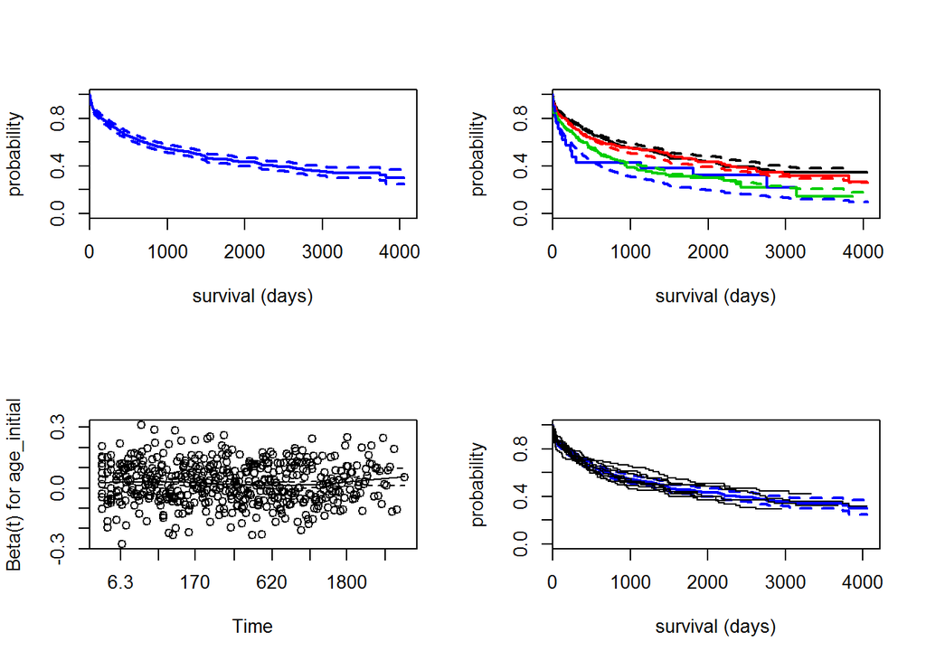

```
## Failure...
```

```
## Expected:
```

```
## [[1]]
## [[1]]$x
## [1] 4052
##
## [[1]]$y
## [1] 0.3037479
##
##
## [[2]]
## [[2]]$x
## [1] 4046 4043 3855 3109
##
## [[2]]$y
## [1] 0.3496556 0.2642009 0.1465661 0.2176871
##
##
## [[3]]
## NULL
##
## [[4]]
## [[4]]$x
## [1] 4052
##
## [[4]]$y
## [1] 0.3037479
##
##
## [[5]]
##                 rho chisq    p
## age_initial -0.0142 0.102 0.75
```

```
## Actual:
```

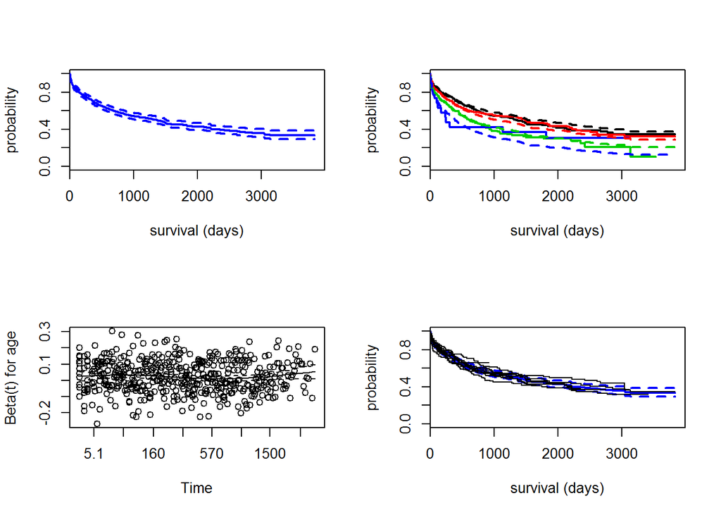

```
##         rho chisq   p
## age -0.0243 0.275 0.6
```

```r
test_output(survival_modelling_diagnostics_current_output, survival_modelling_diagnostics_dev)
```

Here the output looks different; we seem to have lost a year of survival data. Next we will break the function up into smaller ones to generate each plot individually (basically there is no longer an outer function):

```r
survival_modelling_diagnostics_dev <- function() {
    par(mfrow=c(2,2))
    registry_data_r <- registry_data[registry_data$entrydate >= "2004-01-30", ]

    km <- survfit(Surv(time, status) ~ 1, data=registry_data_r)
    plot(km, lwd=2, col="blue", xlab="survival (days)", ylab="probability")

    ages = c(55, 65, 75, 85, 100)
    km2 <- survfit(Surv(time, status) ~ cut(age, breaks=ages), data=registry_data_r)
    plot(km2, lwd=2, col=1:length(ages), xlab="survival (days)", ylab="probability")

    cx <- coxph(Surv(time, status) ~ age, data=registry_data_r)
    cxp <- survfit(cx,
               newdata=data.frame(age=vapply(seq(length(ages) - 1),
                                                function(i) mean(c(ages[i], ages[i + 1])),
                                                numeric(1))))
    lines(cxp, lwd=2, col=1:length(ages), lty=2, mark.time=F)

    plot(cox.zph(cx))

    plot(km, lwd=2, col="blue", mark.time=F, conf.int=T, xlab="survival (days)", ylab="probability")
    num_reg_years <- 9
    registry_years <- .determine_registry_years(start='2004-01-30', num_reg_years=num_reg_years)
    sapply(seq(num_reg_years),
           function(i) lines(survfit(Surv(time, status) ~ 1,
                                 data=registry_data_r[registry_data_r$entrydate >=
                                                          registry_years[i] &
                                                          registry_data_r$entrydate <
                                                          registry_years[i + 1], ]),
                         mark.time = F, conf.int = F))
    return(cox.zph(cx))
}
```

```r
survival_modelling_diagnostics_current_output <- function() {
  par(mfrow=c(2,2))
  result <- survival_modelling_diagnostics_current(registry_data, ages = c(55, 65, 75, 85, 100),
                                         registry_years, registry_start_year, registry_end_year)
}
```

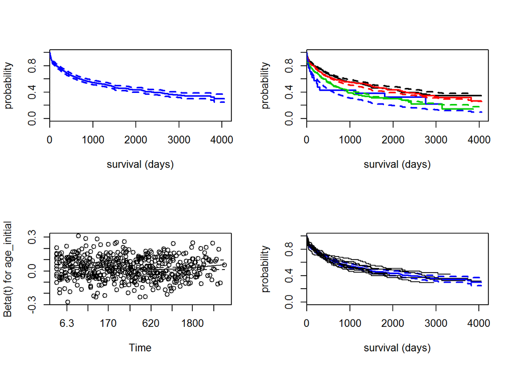

```
## Failure...
```

```
## Expected:
```

```
## [[1]]
## [[1]]$x
## [1] 4052
##
## [[1]]$y
## [1] 0.3037479
##
##
## [[2]]
## [[2]]$x
## [1] 4046 4043 3855 3109
##
## [[2]]$y
## [1] 0.3496556 0.2642009 0.1465661 0.2176871
##
##
## [[3]]
## NULL
##
## [[4]]
## [[4]]$x
## [1] 4052
##
## [[4]]$y
## [1] 0.3037479
##
##
## [[5]]
##                 rho chisq    p
## age_initial -0.0142 0.102 0.75
```

```
## Actual:
```

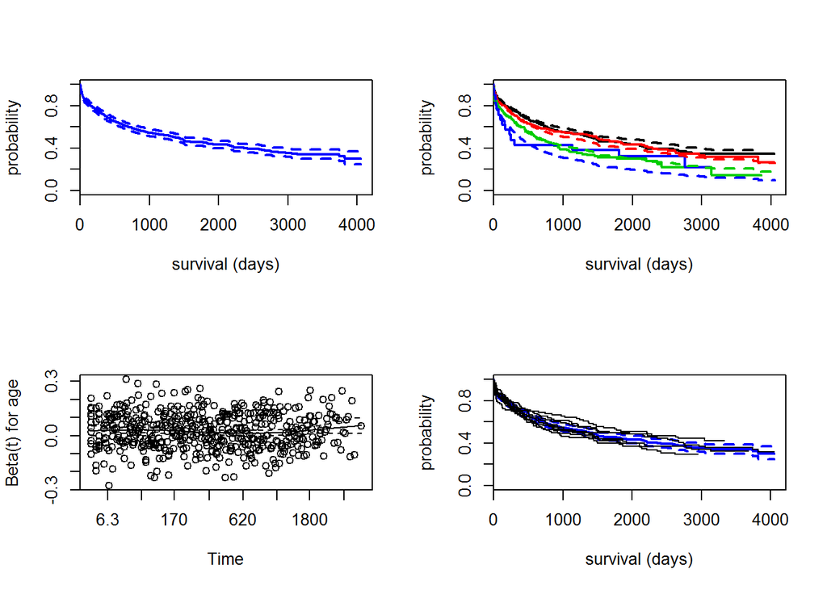

```
##         rho chisq    p
## age -0.0142 0.102 0.75
```

```r
test_output(survival_modelling_diagnostics_current_output, survival_modelling_diagnostics_dev)
```

The output here is clearly the same, however the unit test fails.

## sim_check

```r
sim_check_dev <- function() {
  sim_check(incidence(registry_data$entrydate))
}
```

```r
sim_check_current_output <- function() {
  sim_check_current(incidence(registry_data$entrydate))
}
```

```r
test_output(sim_check_current_output, sim_check_dev)
```

```
## Success!
```

Success was achieved, then seed fixing was removed.

## smoothed_incidence

```r
smo_dev <- function() {
  par(mfrow=c(2,2))
  smoothed_incidence(registry_data$entrydate, start = "2004-01-30", num_reg_years = 9)
}
```

```r
smo_current_output <- function() {
  par(mfrow=c(2,2))
  smoothed_incidence_current(registry_data$entrydate, start = "2004-01-30", num_reg_years = 9)
}
```

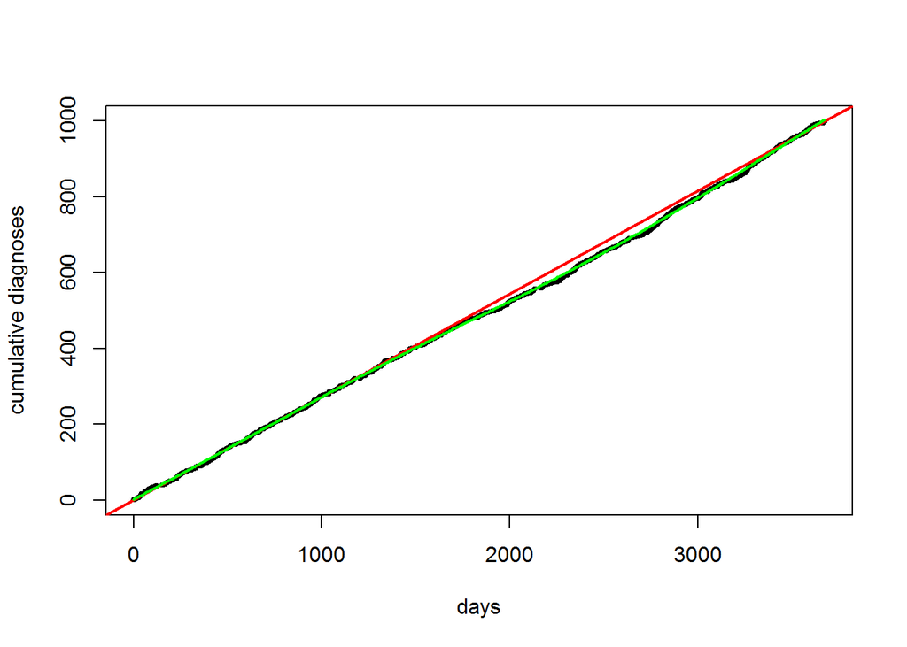

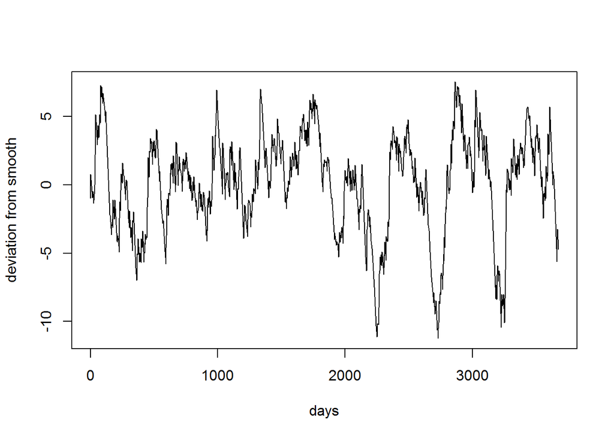

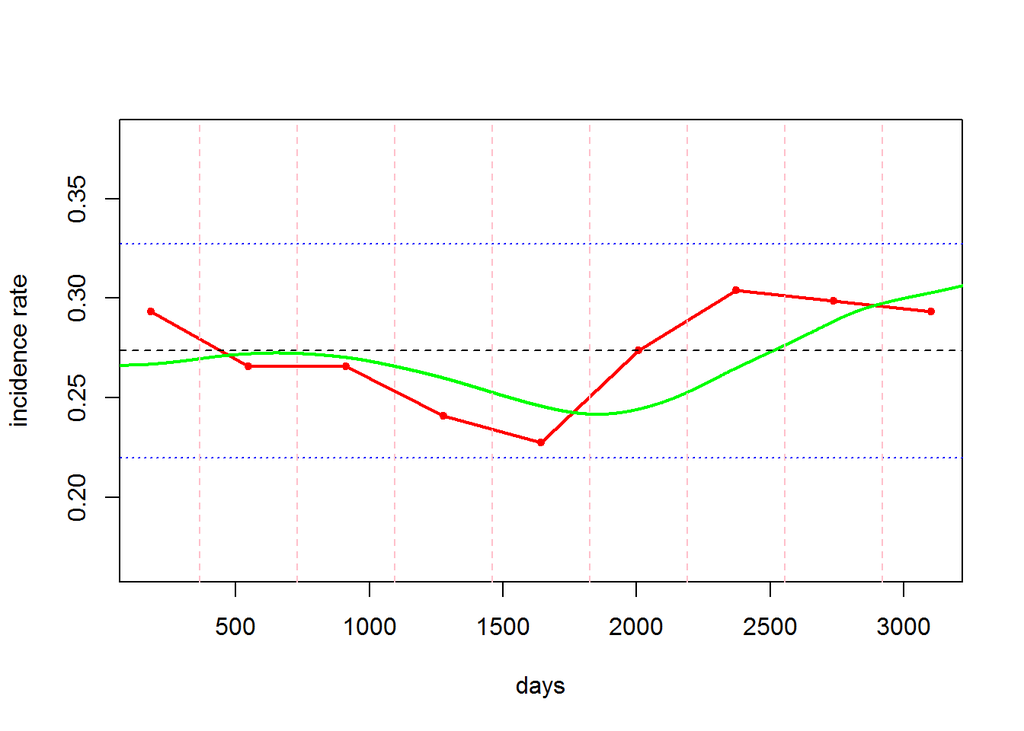

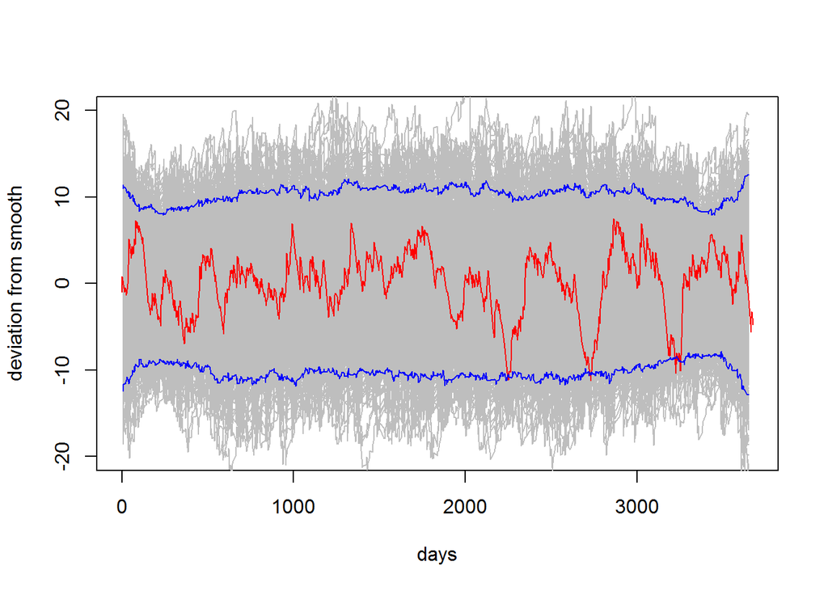

```
## Success!
```

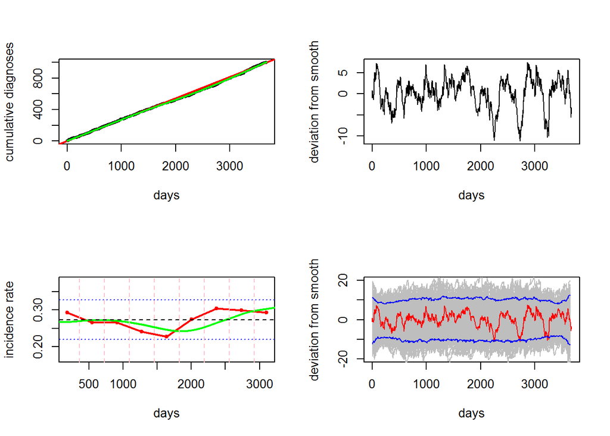

```r
test_output(smo_current_output, smo_dev)
```

Success was achieved. Next we will break the function up into smaller ones to generate each plot individually and unit test again:

```r
smo_dev2 <- function() {
    par(mfrow=c(2,2))
    c_inc <- cumulative_incidence(registry_data$entrydate, start = "2004-01-30", num_reg_years = 9)
    cum_inc <- c_inc$cumulative_incidence
    smooth <- c_inc$smooth

    plot(ordered_diagnoses, seq(length(ordered_diagnoses)), pch=20,
     cex=0.7, xlab="days", ylab="cumulative diagnoses")
    abline(a=0, b=length(ordered_diagnoses)/ordered_diagnoses[length(ordered_diagnoses)],
       col="red", lwd=2)
    lines(smooth, col="green", lwd=2)

    plot(ordered_diagnoses, seq(length(ordered_diagnoses)) - predict(smooth, ordered_diagnoses)$y,
     type="l", xlab="days", ylab="deviation from smooth")

    inspect_incidence(c_inc)
    poisson_incidence_sim(c_inc)
}
```

```r
smo_current_output2 <- function() {
  par(mfrow=c(2,2))
  smoothed_incidence(registry_data$entrydate, start = "2004-01-30", num_reg_years = 9)
}
```

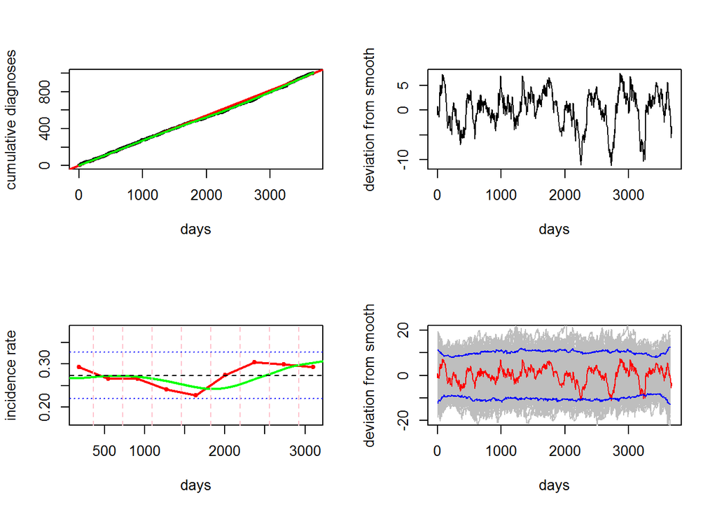

```
## Success!
```

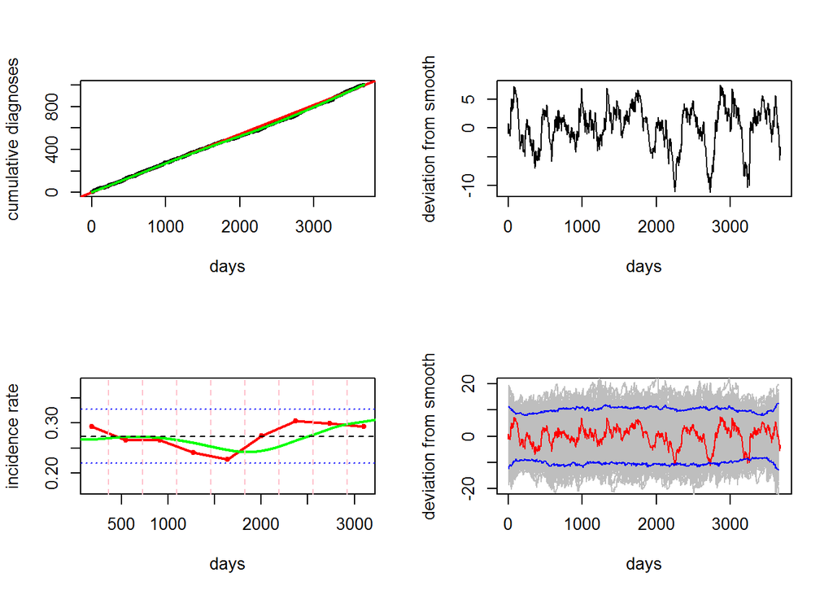

```r
test_output(smo_current_output2, smo_dev2)
```

Success was achieved, so we took out the random number seed specification.